# Market Segmentation for a B2B Company

**Aung Myint Thein (INSEAD eLab)**

### Introduction

The client is the second largest global diversified chemical company in the world, with over $50 billion in revenue. The client manufactures chemicals, fertilizers, metals, and plastics in more than 60 locations around the world. The clients' innovative plastics business is committed to collaborating with customers to leverage the extensive product portfolio of thermoplastic resins, coatings, specialty compounds, film, and sheet materials as well as the broad industry expertise.

This report will analyze the data to identify key input variables for the segmentation using through factor analysis using 80% of the provided data. After analyzing with factor analysis and cluster analysis, I will provide (2-5) segments which represent clusters with specific and differential needs. After that, I will use classification to develop a modal for placing specific customer in one of the segments and will provide the accuracy of the modal with hit ratios, confusion matrix, ROC curves, Lift curves, and Profit curves. Finally, I will access the accuracy of the modal using 10% of the data and will recommend what additional data should be gathered in a possible new customer survey.

### Factor Analysis

#### Customer survey outline

In 2013 the company held a customer survey to understand the needs for companies to select a plastics material supplier. In total almost 1800 customers were interviewed. However, after removing the missing data, our analysis will be based on 1775 rows of data.

The survey results are provided anonymously in the excel file. Customer names and specific customer needs are not mentioned. The data set does include the following variables:

- Data set
- Respondent number (there could be more than one respondent in one company)
- Company number
- Pole (Europe, America, APAC)
- Type of function of the respondent
- Place in value chain
- Max_Diff relative importance of the 20 needs mentioned above (Need_1 to Need_20)
- Behavioral information (20)

The behavioral variables are either binary or measured on a 5-point scale:

a. The 5 point-scale is defined as:

- Very unlikely = 1
- Unlikely = 2
- Do not know = 3
- Likely = 4
- Very likely = 5

b. The binary scale is defined as:

- Yes = 1
- No = 0

#### Checking the data

Having some variables with a very different range/scale can often create problems: **most of the “results” may be driven by a few large values**, more so that we would like. To avoid such issues, one has to consider whether or not to **standardize the data** by making some of the initial raw attributes have, for example, mean 0 and standard deviation 1 (e.g. scaled_low_materaial_price = (low_materaial_price-mean(low_materaial_price))/sd(low_materaial_price) ), or scaling them between 0 and 1 (e.g. scaledlow_materaial_price=(low_materaial_price-min(low_materaial_price))/(max(low_materaial_price)-min(low_materaial_price))). Here is for example the R code for the first approach, if we want to standardize all attributes:

```r
ProjectDatafactor_scaled = apply(ProjectDataFactor, 2, function(r) {
    if (sd(r) != 0)
        res = (r - mean(r))/sd(r) else res = 0 * r
    res
})
```

However, note that for this data, all customer needs survey data are on a similar scale. So, I have decided **not to standardize the data and to use original values.**

#### Check correlation matrix to see if Factor Analysis makes sense

The type of dimensionality reduction methods we will use here “groups together raw attributes that are highly correlated”. Other methods (there are many!) use different criteria to create derived variables. For this to be feasible, it is necessary that the original raw attributes do have large enough correlations (e.g. more than 0.5 in absolute value, or simply statistically significant). It is therefore useful to see the correlation matrix of the original attributes - something that one should anyway always do in order to develop a better understanding of the data.

Following is the correlation matrix of the 20 original variable we use for factor analysis.

|  | MAXDIFF: Material selection support | MAXDIFF: Processing support | MAXDIFF: Application development support | MAXDIFF: Total system cost reduction | MAXDIFF: Efficient and reliable ordering process | MAXDIFF: Delivery &amp; inventory management | MAXDIFF: Low material price | MAXDIFF: Formula based or fixed material price | MAXDIFF: Material coloring solutions | MAXDIFF: Account manager relationship | MAXDIFF: Collaboration during your innovation process | MAXDIFF: Collaboration for growth | MAXDIFF: Support towards your sustainability goals | MAXDIFF: Material quality | MAXDIFF: Supplier expertise of your industry | MAXDIFF: Global service and operations | MAXDIFF: Local service and operations | MAXDIFF: Business services | MAXDIFF: Credit limit. financing and payment terms | MAXDIFF: Broad material portfolio |
| --- | --- | --- | --- | --- | --- | --- | --- | --- | --- | --- | --- | --- | --- | --- | --- | --- | --- | --- | --- | --- |
| MAXDIFF: Material selection support | 1.00 | 0.37 | 0.60 | -0.35 | -0.44 | -0.54 | -0.38 | -0.45 | 0.17 | -0.06 | 0.54 | 0.01 | 0.01 | -0.10 | 0.33 | -0.04 | -0.23 | -0.19 | -0.48 | 0.24 |
| MAXDIFF: Processing support | 0.37 | 1.00 | 0.43 | -0.34 | -0.30 | -0.33 | -0.39 | -0.37 | 0.16 | -0.07 | 0.32 | -0.03 | -0.06 | 0.02 | 0.22 | -0.06 | -0.10 | -0.15 | -0.29 | 0.06 |
| MAXDIFF: Application development support | 0.60 | 0.43 | 1.00 | -0.34 | -0.47 | -0.60 | -0.49 | -0.51 | 0.04 | -0.21 | 0.67 | 0.16 | 0.14 | -0.17 | 0.36 | -0.04 | -0.18 | -0.10 | -0.44 | 0.21 |
| MAXDIFF: Total system cost reduction | -0.35 | -0.34 | -0.34 | 1.00 | 0.05 | 0.14 | 0.53 | 0.37 | -0.26 | -0.12 | -0.28 | -0.16 | -0.05 | 0.00 | -0.30 | -0.09 | -0.05 | -0.05 | 0.22 | -0.27 |
| MAXDIFF: Efficient and reliable ordering process | -0.44 | -0.30 | -0.47 | 0.05 | 1.00 | 0.67 | 0.14 | 0.21 | -0.10 | 0.01 | -0.49 | -0.26 | -0.12 | 0.18 | -0.26 | -0.19 | 0.08 | 0.12 | 0.33 | -0.19 |
| MAXDIFF: Delivery &amp; inventory management | -0.54 | -0.33 | -0.60 | 0.14 | 0.67 | 1.00 | 0.30 | 0.35 | -0.06 | 0.04 | -0.65 | -0.27 | -0.22 | 0.23 | -0.34 | -0.15 | 0.17 | 0.02 | 0.37 | -0.25 |
| MAXDIFF: Low material price | -0.38 | -0.39 | -0.49 | 0.53 | 0.14 | 0.30 | 1.00 | 0.51 | -0.16 | 0.01 | -0.54 | -0.20 | -0.28 | 0.10 | -0.38 | -0.10 | -0.06 | -0.07 | 0.29 | -0.22 |
| MAXDIFF: Formula based or fixed material price | -0.45 | -0.37 | -0.51 | 0.37 | 0.21 | 0.35 | 0.51 | 1.00 | -0.19 | 0.01 | -0.49 | -0.22 | -0.25 | 0.01 | -0.37 | -0.09 | -0.05 | 0.00 | 0.33 | -0.18 |
| MAXDIFF: Material coloring solutions | 0.17 | 0.16 | 0.04 | -0.26 | -0.10 | -0.06 | -0.16 | -0.19 | 1.00 | -0.03 | 0.06 | -0.10 | -0.12 | 0.08 | -0.01 | -0.02 | -0.02 | -0.13 | -0.14 | 0.04 |
| MAXDIFF: Account manager relationship | -0.06 | -0.07 | -0.21 | -0.12 | 0.01 | 0.04 | 0.01 | 0.01 | -0.03 | 1.00 | -0.12 | 0.01 | -0.20 | -0.10 | -0.09 | -0.04 | 0.01 | 0.03 | -0.06 | -0.20 |
| MAXDIFF: Collaboration during your innovation process | 0.54 | 0.32 | 0.67 | -0.28 | -0.49 | -0.65 | -0.54 | -0.49 | 0.06 | -0.12 | 1.00 | 0.29 | 0.24 | -0.18 | 0.31 | 0.03 | -0.23 | -0.15 | -0.46 | 0.18 |
| MAXDIFF: Collaboration for growth | 0.01 | -0.03 | 0.16 | -0.16 | -0.26 | -0.27 | -0.20 | -0.22 | -0.10 | 0.01 | 0.29 | 1.00 | 0.11 | -0.25 | 0.11 | 0.08 | -0.13 | -0.05 | -0.15 | 0.06 |
| MAXDIFF: Support towards your sustainability goals | 0.01 | -0.06 | 0.14 | -0.05 | -0.12 | -0.22 | -0.28 | -0.25 | -0.12 | -0.20 | 0.24 | 0.11 | 1.00 | -0.06 | 0.06 | 0.04 | -0.03 | 0.17 | -0.15 | 0.06 |
| MAXDIFF: Material quality | -0.10 | 0.02 | -0.17 | 0.00 | 0.18 | 0.23 | 0.10 | 0.01 | 0.08 | -0.10 | -0.18 | -0.25 | -0.06 | 1.00 | -0.12 | -0.06 | -0.10 | -0.03 | -0.03 | -0.11 |
| MAXDIFF: Supplier expertise of your industry | 0.33 | 0.22 | 0.36 | -0.30 | -0.26 | -0.34 | -0.38 | -0.37 | -0.01 | -0.09 | 0.31 | 0.11 | 0.06 | -0.12 | 1.00 | -0.07 | -0.11 | -0.01 | -0.29 | 0.10 |
| MAXDIFF: Global service and operations | -0.04 | -0.06 | -0.04 | -0.09 | -0.19 | -0.15 | -0.10 | -0.09 | -0.02 | -0.04 | 0.03 | 0.08 | 0.04 | -0.06 | -0.07 | 1.00 | 0.17 | -0.01 | -0.20 | 0.08 |
| MAXDIFF: Local service and operations | -0.23 | -0.10 | -0.18 | -0.05 | 0.08 | 0.17 | -0.06 | -0.05 | -0.02 | 0.01 | -0.23 | -0.13 | -0.03 | -0.10 | -0.11 | 0.17 | 1.00 | 0.13 | 0.05 | -0.12 |
| MAXDIFF: Business services | -0.19 | -0.15 | -0.10 | -0.05 | 0.12 | 0.02 | -0.07 | 0.00 | -0.13 | 0.03 | -0.15 | -0.05 | 0.17 | -0.03 | -0.01 | -0.01 | 0.13 | 1.00 | 0.12 | -0.09 |
| MAXDIFF: Credit limit. financing and payment terms | -0.48 | -0.29 | -0.44 | 0.22 | 0.33 | 0.37 | 0.29 | 0.33 | -0.14 | -0.06 | -0.46 | -0.15 | -0.15 | -0.03 | -0.29 | -0.20 | 0.05 | 0.12 | 1.00 | -0.18 |
| MAXDIFF: Broad material portfolio | 0.24 | 0.06 | 0.21 | -0.27 | -0.19 | -0.25 | -0.22 | -0.18 | 0.04 | -0.20 | 0.18 | 0.06 | 0.06 | -0.11 | 0.10 | 0.08 | -0.12 | -0.09 | -0.18 | 1.00 |

There are quite a few large (in absolute value) correlations. Therefore, we will proceed to factor analysis.

#### Factor Analysis

While there are as many (and for other methods, more) factors as the number of original raw attributes, since our goal is to identify key input vartiables or factors, we need to make sure not to lose much information when we use only a few of the components.

When using PCA, we have two measures of “how much of the information (variance in this case) in the original raw data is captured by any of the factors”:

a) the *percentage of variance explained*,

b) the *eigenvalue coresponding to the compontent*.

Two Statistical criteria to select the number of factors/derived variables when using PCA are

1. select components with corresponding eigenvalue larger than 1.
2. Select the components with the highest eigenvalues “up to the component” for which the cumulative total variance explained is relatively large (e.g. more than 50%).

Although they are statistical rules, I have decided to use 10 components. The main reason is that up to 6 components, which has eigenvalue larger than 1, can cover only 60.95% of the variance. By having 10 components, I can cover up to 78.44% of the variance which I believe is a more appropriate to do further analysis.

#### Interpretation of the factors

In practice one would like to have derived variables that use only a few of the original raw attributes - while each new derived variable using different subsets of the original raw attributes. Unfortunately this is not necessarily always the case. However, there are mathematical methods, called “factor **rotations**”, which transform the estimated factors into new ones which capture exactly the same information from the raw data but use only few non-overlaping raw attributes. One such rotation often used in practice is called the varimax rotation - but others are also available.

To interpret the selected factors, we often use three **Factor Technical Quality Criteria**:

1. For each factor (column) only a few loadings are large (in absolute value)
2. For each raw attribute (row) only a few loadings are large (in absolute value)
3. Any pair of factors (columns) should have different “patterns” of loading

#### Save factor scores for subsequent analysis

However, once we decided the factors to use, we typically replace the original data with a new dataset where each observation (row) is now described not using the original raw attributes but using instead the selected factors/derived attributes. Afterall this was the goal of this analysis.

The way to represent our observations using the found derived attributes (factors/components) is to estimate for each observation (row) how it “scores” for each of the selected factor. These numbers are called **factor scores**. Effectively they are the “scores” the observation would take on the factor had we measured that factor directly instead of measuring the original raw attributes.

### Clustering and Segmentation

1. Confirm the data in metric
2. Decide whether to scale or standardize the data
3. Decide which variables to use for clustering
4. Define similarity or dissimilarity measures between observations
5. Visualize Individual Attributes and Pair-wise Distances between the Observations
6. Select the clustering method to use and decide how many clusters to have
7. Profile and interpret the clusters
8. Assess the robustness of our clusters

Let's follow these steps.

#### Step 1. Confirm the data in metric

In our case the data are metric, so we continue to the next step.

#### Step 3. Decide which variables to use for clustering

Currently, we have decided to use the factor scores from factor analysis above which is statistically more accurate.

#### Step 4. Define similarity or dissimilarity measures between observations

In our case we explore two distance metrics: the commonly used **Euclidean distance** as well as **Manhattan distance**.

Pairwise Distances between the first 5 observations using The Euclidean Distance Metric

|  | 1 | 2 | 3 | 4 | 5 |
| --- | --- | --- | --- | --- | --- |
| 1 | 0.0 |  |  |  |  |
| 2 | 3.5 | 0.0 |  |  |  |
| 3 | 3.6 | 2.9 | 0.0 |  |  |
| 4 | 4.8 | 4.1 | 4.1 | 0.0 |  |
| 5 | 3.6 | 4.7 | 4.0 | 4.9 | 0.0 |

Notice for example that if we use, say, the Manhattan distance metric, these distances change as follows:

Pairwise Distances between the first 5 observations using The Manhattan Distance Metric

|  | 1 | 2 | 3 | 4 | 5 |
| --- | --- | --- | --- | --- | --- |
| 1 | 0.0 |  |  |  |  |
| 2 | 6.1 | 0.0 |  |  |  |
| 3 | 7.3 | 7.1 | 0.0 |  |  |
| 4 | 12.2 | 10.7 | 9.5 | 0.0 |  |
| 5 | 7.9 | 11.5 | 9.7 | 13.2 | 0.0 |

In general a lot of creative thinking and exploration should be spent in this step, and as always one may need to come back to this step even after finishing the complete segmentation process - multiple times.

#### Step 5. Visualize Individual Attributes and Pair-wise Distances between the Observations

The histogram of all pairwise distances for the euclidean distance:

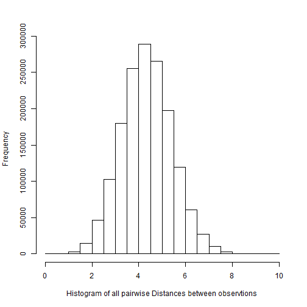

#### Step 6. Select the clustering method to use and decide how many clusters to have

We will explore two widely used methods: **Hierarchical Clustering Method** and **Kmeans Clustering Method**. Like all clustering methods, these two also require that we have decided how to measure the distance/similarity between our observations. The only difference to highlight is that Kmeans requires the user to define how many segments to create, while Hierarchical Clustering does not.

**Hierarchial Clustering**

When we do not know how many segments there are in our data, hierarchical clustering is a method that also helps us visualise how the data may be clustering together. It generates a plot called the **Dendrogram** which is often helpful for visualization - but should be used with care. For example, in this case the dendrogram, using the euclidean distance metric from the earlier steps and the ward hierarchical clustering option (see below as well as help(hclust) in R for more information), is as follows:

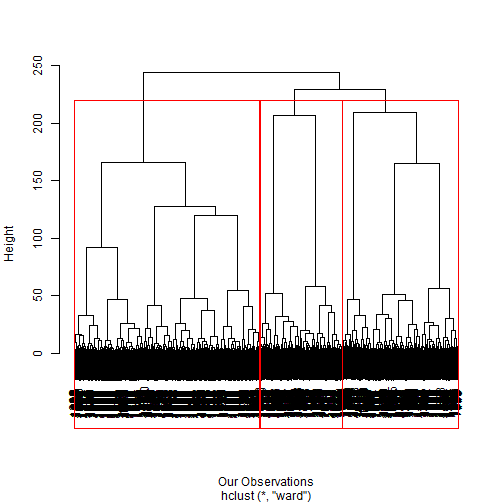

Note that we can draw as many clusters as we choose (e.g. in this case we chose 3 clusters) around the branches of the Dendrogram. We can also plot the “distances” traveled before we need to merge any of the lower and smaller in size clusters into larger ones - the heights of the tree branches that link the clusters as we traverse the tree from its leaves to its root. If we have n observations, this plot has n-1 numbers.

**Kmean Clustering**

#### Step 7. Profile and interpret the clusters

We can also “visualize” the segments using **snake plots** for each cluster. For example, we can plot the means of the profiling variables for each of our clusters to better visualize differences between segments. For better visualization, we plot the standardized profiling variables.

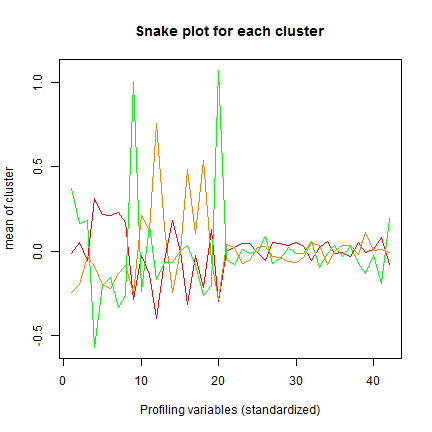

We can also compare the averages of the profiling variables of each segment relative to the average of the variables across the whole population. This can also help us better understand whether there are indeed clusters in our data (e.g. if all segments are much like the overall population, there may be no segments). For example, we can measure the ratios of the average for each cluster to the average of the population (e.g. average of cluster/average of population) and explore a table as following:

|  | Segment 1 | Segment 2 | Segment 3 |
| --- | --- | --- | --- |
| MAXDIFF: Material selection support | 0.9907 | 0.8269 | 1.263 |
| MAXDIFF: Processing support | 1.037 | 0.8504 | 1.125 |
| MAXDIFF: Application development support | 0.9534 | 0.9716 | 1.144 |
| MAXDIFF: Total system cost reduction | 1.15 | 0.9564 | 0.7245 |
| MAXDIFF: Efficient and reliable ordering process | 1.206 | 0.8073 | 0.807 |
| MAXDIFF: Delivery &amp; inventory management | 1.165 | 0.8247 | 0.8761 |
| MAXDIFF: Low material price | 1.116 | 0.9339 | 0.8322 |
| MAXDIFF: Formula based or fixed material price | 1.146 | 0.9257 | 0.7766 |
| MAXDIFF: Material coloring solutions | 0.6062 | 0.653 | 2.371 |
| MAXDIFF: Account manager relationship | 0.9802 | 1.168 | 0.8097 |
| MAXDIFF: Collaboration during your innovation process | 0.896 | 1.088 | 1.11 |
| MAXDIFF: Collaboration for growth | 0.4952 | 1.96 | 0.7894 |
| MAXDIFF: Support towards your sustainability goals | 0.9283 | 1.177 | 0.9136 |
| MAXDIFF: Material quality | 1.04 | 0.9463 | 0.9856 |
| MAXDIFF: Supplier expertise of your industry | 0.9997 | 0.9975 | 1.004 |
| MAXDIFF: Global service and operations | 0.5866 | 1.632 | 1.044 |
| MAXDIFF: Local service and operations | 0.9745 | 1.102 | 0.9149 |
| MAXDIFF: Business services | 0.6323 | 1.911 | 0.5496 |
| MAXDIFF: Credit limit. financing and payment terms | 1.187 | 0.9091 | 0.7072 |
| MAXDIFF: Broad material portfolio | 0.5425 | 0.5522 | 2.655 |
| Willing to Changing suppliers | 0.9984 | 1.017 | 0.9804 |
| Willing to Give more business | 1.005 | 1.005 | 0.9821 |
| Willing to Recommend to others | 1.011 | 0.9815 | 1.002 |
| Willing to Specify as supplier of choice | 1.008 | 0.989 | 0.9971 |
| Willing to Pay for consulting services | 0.9956 | 1.009 | 0.998 |
| Willing to Pay price premium | 0.9773 | 1.01 | 1.036 |
| Changed material suppliers in past | 1.023 | 0.9859 | 0.9678 |
| Given more business in past | 1.021 | 0.9819 | 0.9782 |
| Recommended to others in past | 1.019 | 0.9595 | 1.014 |
| Specify as supplier of choice in past | 1.027 | 0.9628 | 0.9905 |
| Paid for consulting services in past | 1.075 | 0.9062 | 0.9621 |
| Paid premium in past | 0.8819 | 1.106 | 1.117 |
| Will - Order large quantity for lower price | 1.006 | 1.011 | 0.9706 |
| Will accept - No sales rep for lower price | 1.023 | 0.967 | 0.9953 |
| Will accept - Cancellation fees for lower price | 0.9942 | 0.9993 | 1.014 |
| Will accept - Longer lead times for lower price | 0.9962 | 1.016 | 0.9863 |
| Will accept - Broader materials specs for lower price | 0.9868 | 1.012 | 1.012 |
| Will - Use own transportation for lower price | 1.019 | 0.991 | 0.9696 |
| Will - Allocate more spending to supplier for lower price | 0.997 | 1.029 | 0.9667 |
| Will - Give up support for lower price | 1.005 | 1.001 | 0.9869 |
| Price Importance | 1.025 | 1.003 | 0.9395 |
| Quality and service importance | 0.9726 | 0.9966 | 1.066 |

From above table and snake plot, we can easily see that segments appear distinct with one high, one medium, and one low impact segment per specific needs. Based on this cluster analysis, we can define customer segments as :

1. Matured clients
2. Entry level clients
3. Support oriented and cash rich clients

Using the table above, we can describe the specific and differentiated needs of segments as following :

**1. Matured clients**

These customers are mature businesses and there are total 315 clients (17.75% of whole dataset). They needs their supplier to have an efficient and reliable ordering process (20.61% higher than population average), delivery & inventory management (16.45% higher than population average), and formula based or fixed material price (14.58% higher than population average). This shows that they are more mature and process based clients and they want certainty and predictability in their cost. This is strengthened more by having 18.7 percent higher than population average in needs of credit limit, financing and payment terms and the highest among 3 segments.

Since they are already matured, clients from this segment do not care and need so much of collaboration for growth (50.48% lower than population average), global service and operations (41.34% lower than population average), business services (36.77% lower than population average). They seem to know of what they want as they do not need their supplier to have broad material portfolio (45.75% lower than population average).

**2. Entry level clients**

These customers are entry level business and they are total 798 clients (44.96% of whole dataset). Since they are entry level businesses, they are willing to collaborate for growth (95.99% higher than population average) and they needs their supplier support towards their sustainabile goals (17.67% higher than population average). Being an entry level businesses, they also want dedicated account manager relationship (16.77% higher than population average) and they need their supplier to have a strong business services (91.12% higher than population average) and global service and operations (63.18% higher than population average).

Strangely, they are not very much interested in material coloring solutions (34.7% lower than population average) and broad material portfolio (44.78% lower than population average). This may be because they are entry level businesses and they still do not need sophisticated and advanced services.

Most importantly, they paid premium in the past (10.59% higher than population average) and therefore, they are valuable customers. However, they have highest average score in “willing to change supplier” with 1.02 among all segments. So, we need to pay more attention to this segments as this segment has a lot of room to improve and can grow the business and our subsequent analysis will be based on this segment.

**3. Support oriented and cash rich clients**

These customers are support oriented and cash rich clients and they are total 662 clients (37.3% of whole dataset). They rate highly generally on support related questions such as material selection support (26.34% higher than population average), processing support (12.55% higher than population average), and application development support (14.44% higher than population average). Interestingly, they need supplier with significantly broad material portfolio (165.46% higher than population average) and material coloring solutions (137.05% higher than population average). May be because their need of products are diversed and therefore, they rate less for fixed material price (check below). As support oriented clients, they are more interested to collaborate during innovation process (11.02% higher than population average) than collaboration for growth (21.06% lower than population average).

They definitely are cash rish clients. They rate generally lower than population average for cost related needs such as total system cost reduction (27.55% lower than population average) and formula based or fixed material price (22.34% lower than population average). They do not need credit limit, financing and payment terms (29.28% lower than population average). This segment of clients paid premium the most among all the segments (11.7% higher than population average) and least willing to change supplier (1.96% lower than population average).

#### Step 8. Assess the robustness of our clusters

We will skip this step for this exercise. However in practice this is a very important step.

### Classification

After analyzing the survey data (using factor and cluster analysis), we decided to only focus on the second segment : **“Entry level clients”** which they thought were the most important ones. They decided to perform the classification and drivers analysis using only the responses to the behavioral questions to develop a modal for placing specific customer or client in the selected segment as following :

1. “Willing to Changing suppliers”
2. “Willing to Give more business”
3. “Willing to Recommend to others”
4. “Willing to Specify as supplier of choice”
5. “Willing to Pay for consulting services”
6. “Willing to Pay price premium”
7. “Changed material suppliers in past”
8. “Given more business in past”
9. “Recommended to others in past”
10. “Specify as supplier of choice in past”
11. “Paid for consulting services in past”
12. “Paid premium in past”
13. “Will - Order large quantity for lower price”
14. “Will accept - No sales rep for lower price”
15. “Will accept - Cancellation fees for lower price”
16. “Will accept - Longer lead times for lower price”
17. “Will accept - Broader materials specs for lower price”
18. “Will - Use own transportation for lower price”
19. “Will - Allocate more spending to supplier for lower price”
20. “Will - Give up support for lower price”

#### Classification in 6 steps

We will follow the 6 steps as below for classification.

1. Create an estimation sample and two validation samples by splitting the data into three groups. Steps 2-5 below will then be performed only on the estimation and the first validation data. You should only do step 6 once on the second validation data, also called **test data**, and report/use the performance on that (second validation) data only to make final business decisions.
2. Set up the dependent variable (as a categorical 0-1 variable; multi-class classification is also feasible, and similar, but we do not explore it in this note).
3. Make a preliminary assessment of the relative importance of the explanatory variables using visualization tools and simple descriptive statistics.
4. Estimate the classification model using the estimation data, and interpret the results.
5. Assess the accuracy of classification in the first validation sample, possibly repeating steps 2-5 a few times in different ways to increase performance.
6. Finally, assess the accuracy of classification in the second validation sample. You should eventually use/report all relevant performance measures/plots on this second validation sample only.

#### Step 1: Splitting the data into estimation and validation samples

Since we are using variables with different scales for independent variables, we normalized our data using as following:

```r
ProjectDatafactor_Example <- apply(ProjectData, 2, function(r) {
    if (sd(r) != 0)
        res = (r - mean(r))/sd(r) else res = 0 * r
    res
})
```

We will use 80% of the dataset as estimation data (1420 observations), 10% of the dataset as validation data (177 observations), and 10% as test data (178 observations).

#### Step 2: Setting up the dependent variable

In our data, the number of 0/1's in our estimation sample is as follows:

Number of Observations per class in the Estimation Sample

|  | Class 1 (Cluster 2) | Class 0 (Other clusters) |
| --- | --- | --- |
| # of Observations | 619 | 801 |

while in the validation sample they are:

Number of Observations per class in the Validation Sample

|  | Class 1 (Cluster 2) | Class 0 (Other clusters) |
| --- | --- | --- |
| # of Observations | 93 | 84 |

#### Step 3: Make a preliminary assessment of the relative importance of the explanatory variables using visualization tools and simple descriptive statistics.

First one is for Actual 1 and second one is for Actual 0.

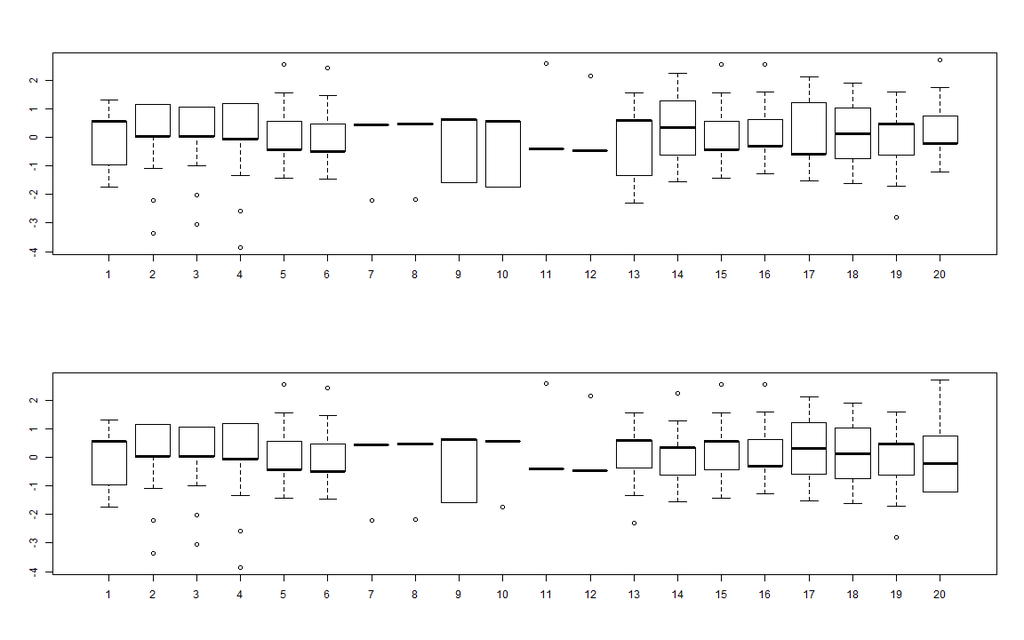

#### Step 4: Estimate the classification model using the estimation data, and interpret the results.

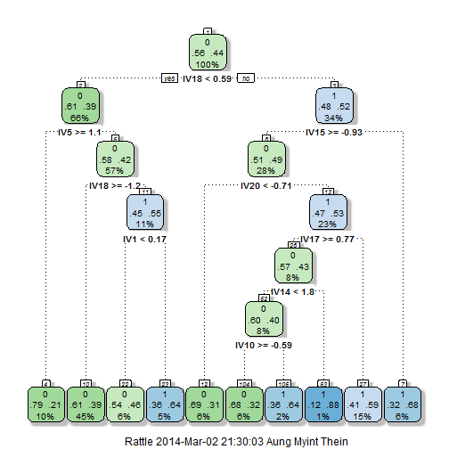

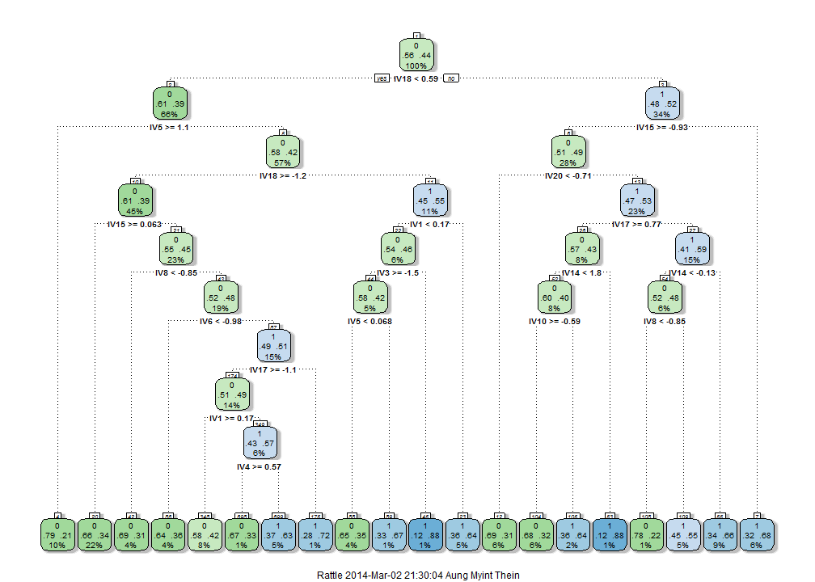

In practice we need to select the **probability threshold** above which we consider an observation as “class 1”: this is an important choice that we will discuss below. First we discuss another method widely used, namely logistic regression.

**Logistic Regression** is a method similar to linear regression except that the dependent variable can be discrete (e.g. 0 or 1). **Linear** logistic regression estimates the coefficients of a linear model using the selected independent variables while optimizing a classification criterion. For example, this is the logistic regression parameters for our data:

Logistic Regression: Estimated Coefficients

|  | Estimate | Std. Error | z value | Pr(> \|z\|) |
| --- | --- | --- | --- | --- |
| (Intercept) | -0.3 | 0.1 | -5.0 | 0.0 |
| Willing.to.Changing.suppliers | -0.1 | 0.1 | -1.2 | 0.2 |
| Willing.to.Give.more.business | 0.1 | 0.1 | 1.1 | 0.3 |
| Willing.to.Recommend.to.others | -0.0 | 0.1 | -0.2 | 0.9 |
| Willing.to.Specify.as.supplier.of.choice | 0.0 | 0.1 | 0.0 | 1.0 |
| Willing.to.Pay.for.consulting.services | -0.1 | 0.1 | -1.8 | 0.1 |
| Willing.to.Pay.price.premium | -0.0 | 0.1 | -0.4 | 0.7 |
| Changed.material.suppliers.in.past | -0.0 | 0.1 | -0.4 | 0.7 |
| Given.more.business.in.past | 0.2 | 0.1 | 2.3 | 0.0 |
| Recommended.to.others.in.past | -0.1 | 0.1 | -0.8 | 0.4 |
| Specify.as.supplier.of.choice.in.past | -0.0 | 0.1 | -0.6 | 0.5 |
| Paid.for.consulting.services.in.past | -0.1 | 0.1 | -1.5 | 0.1 |
| Paid.premium.in.past | 0.0 | 0.1 | 0.2 | 0.8 |
| Will…Order.large.quantity.for.lower.price | -0.0 | 0.1 | -0.2 | 0.9 |
| Will.accept…No.sales.rep.for.lower.price | 0.1 | 0.1 | 1.7 | 0.1 |
| Will.accept…Cancellation.fees.for.lower.price | -0.2 | 0.1 | -3.4 | 0.0 |
| Will.accept…Longer.lead.times.for.lower.price | 0.0 | 0.1 | 0.5 | 0.6 |
| Will.accept…Broader.materials.specs.for.lower.price | -0.1 | 0.1 | -1.8 | 0.1 |
| Will…Use.own.transportation.for.lower.price | 0.1 | 0.1 | 2.2 | 0.0 |
| Will…Allocate.more.spending.to.supplier.for.lower.price | 0.1 | 0.1 | 1.2 | 0.2 |
| Will…Give.up.support.for.lower.price | 0.2 | 0.1 | 3.8 | 0.0 |

|  | CART 1 | CART 2 | Logistic Regr. |
| --- | --- | --- | --- |
| Willing.to.Changing.suppliers | -0.1622 | -0.3039 | -0.3158 |
| Willing.to.Give.more.business | 0.02056 | 0.08682 | 0.2895 |
| Willing.to.Recommend.to.others | -0.06592 | -0.2464 | -0.05263 |
| Willing.to.Specify.as.supplier.of.choice | 0.00 | 0.00 | 0.00 |
| Willing.to.Pay.for.consulting.services | -0.6477 | -0.8298 | -0.4737 |
| Willing.to.Pay.price.premium | -0.04318 | -0.2001 | -0.1053 |
| Changed.material.suppliers.in.past | -0.01456 | -0.06226 | -0.1053 |
| Given.more.business.in.past | 0.009448 | 0.3306 | 0.6053 |
| Recommended.to.others.in.past | -0.009448 | -0.008919 | -0.2105 |
| Specify.as.supplier.of.choice.in.past | -0.2646 | -0.2497 | -0.1579 |
| Paid.for.consulting.services.in.past | -0.04318 | -0.04964 | -0.3947 |
| Paid.premium.in.past | 0.00 | 0.02358 | 0.05263 |
| Will…Order.large.quantity.for.lower.price | -0.02495 | -0.03928 | -0.05263 |
| Will.accept…No.sales.rep.for.lower.price | 0.2054 | 0.4307 | 0.4474 |
| Will.accept…Cancellation.fees.for.lower.price | -0.2889 | -0.5117 | -0.8947 |
| Will.accept…Longer.lead.times.for.lower.price | 0.01107 | 0.09067 | 0.1316 |
| Will.accept…Broader.materials.specs.for.lower.price | -0.2214 | -0.3337 | -0.4737 |
| Will…Use.own.transportation.for.lower.price | 1.00 | 1.00 | 0.5789 |
| Will…Allocate.more.spending.to.supplier.for.lower.price | 0.1054 | 0.1073 | 0.3158 |
| Will…Give.up.support.for.lower.price | 0.3983 | 0.4038 | 1.00 |

### 1. **Hit ratio**

These are as follows for the probability threshold 50% for the validation data:

Validation Data Hit Ratios for different classifiers tested

|  | Hit Ratio |
| --- | --- |
| First CART | 50.8 |
| Second CART | 53.7 |
| Logistic Regression | 52.5 |

while for the estimation data the hit rates are:

Estimation Data Hit Ratios for different classifiers tested

|  | Hit Ratio |
| --- | --- |
| First CART | 63.5 |
| Second CART | 66.8 |
| Logistic Regression | 58.7 |

**Why are the performances on the estimation and validation data different? How different can they possibly be? What does this diffference depend on?** Is the Validation Data Hit Rate satisfactory? Which classifier should we use? What should be the benchmark against which to compare the hit rate?

### 2. **Confusion matrix**

Confusion Matrix for Validation data

|  | Predicted 1 | Predicted 0 |
| --- | --- | --- |
| Actual 1 | 37.6 | 62.4 |
| Actual 0 | 28.6 | 71.4 |

Note that the percentages add up to 100% for each row: can you see why? Moreover, a “good” confusion matrix should have large diagonal values and small off-diagonal oens: you see why?

### 3. **ROC curve**

which, if we plot all in the same graph for comparison, are (black: CART 1; red: CART 2; blue: logistic regression):

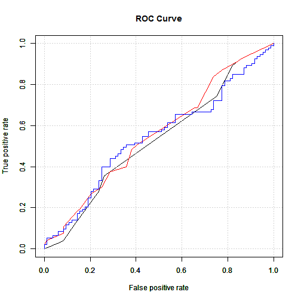

How should a good ROC curve look like? A rule of thumb in assessing ROC curves is that the “higher” the curve, hence the larger the area under the curve, the better. You may also select one point on the ROC curve (the “best one” for our purpose) and use that false positive/false negative performances (and corresponding threshold for P(0)) to assess your model. **Which point on the ROC should we select?**

### 5. **Profit Curve**

Assumed Profits and Costs

|  | Predict 1 | Predict 0 |
| --- | --- | --- |
| Actual 1 | 100.0 | -75.0 |
| Actual 0 | -50.0 | 0.0 |

We can then select the threshold that corresponds to the maximum expected profit (or minimum loss, if necessary).

#### Step 6: Finally, assess the accuracy of classification in the test data.

**Will the performance in the test data be similar to the performance in the validation data above? More important: should we expect the performance of our classification model to be close to that in our test data when we deploy the model in practice? Why or why not? What should we do if they are different?**

The Confusion Matrix for the model with the best validation data hit ratio above:

Confusion Matrix for test data

|  | Predicted 1 | Predicted 0 |
| --- | --- | --- |
| Actual 1 | 48.8 | 51.2 |
| Actual 0 | 40.2 | 59.8 |

which, if we plot all in the same graph for comparison, are (black: CART 1; red: CART 2; blue: logistic regression):

[figure not shown]